# PRA2- Tipologia de Dades

Joana Llauradó & Maria Sopena Rios

2024-01-03

# PRA2- TIPOLOGIA DEDADES

En aquesta pràctica utilitzarem el dataset lliure *Indicators of Heart Disease* de Keggel (https://www.kaggle.com/datasets/kamilpytlak/personal-key-indicators-of-heart-disease) . Aquest conjunt de dades es va obtenir a partor de l’enquesta anual del 2020 dels Centres per al Control i Prevenció de Malalties o, en anglès, Centers for Disease Control and Prevention (CDC) i conte dades de més de 300.000 adults sobre el seu estat de salut.

En aquesta pràctica realitzarem els següents estudis: - **Estudi de Prevalencia**: Estudiar la prevalencia de malalties (Cardiovascular, Infart, Diabetes, Athma, Malalria Renal i Cancer de Pell) estratificada per sexe,raça i edat. - **Estudi d’Associacions**: Segons les prevalencies anteriors escollirem esudiar de les assocaions més remarcables (asthma-edat, malalties cardiovasculars-edat, cancer pell-raça) - **Estudi de Correlacions**: Correlacio de les hores de son (factor de risc de malalties cardiovasculars) i edat. Correlació de cosnum d’alcohol, fumadors, activtiat física amb les hores de son.

## 1. Descripció del dataset

```r
df <- read.csv("../data/heart_2020_original.csv")
dim(df)
```

```
## [1] 319795     18
```

```r
head(df)
```

```
##   HeartDisease   BMI Smoking AlcoholDrinking Stroke PhysicalHealth MentalHealth
## 1           No 16.60     Yes              No     No              3           30
## 2           No 20.34      No              No    Yes              0            0
## 3           No 26.58     Yes              No     No             20           30
## 4           No 24.21      No              No     No              0            0
## 5           No 23.71      No              No     No             28            0
## 6          Yes 28.87     Yes              No     No              6            0
##   DiffWalking    Sex AgeCategory  Race Diabetic PhysicalActivity GenHealth
## 1          No Female       55-59 White      Yes              Yes Very good
## 2          No Female 80 or older White       No              Yes Very good
## 3          No   Male       65-69 White      Yes              Yes      Fair
## 4          No Female       75-79 White       No               No      Good
## 5         Yes Female       40-44 White       No              Yes Very good
## 6         Yes Female       75-79 Black       No               No      Fair
##   SleepTime Asthma KidneyDisease SkinCancer
## 1         5    Yes            No        Yes
## 2         7     No            No         No
## 3         8    Yes            No         No
## 4         6     No            No        Yes
## 5         8     No            No         No
## 6        12     No            No         No
```

Aquest dataset conté informació de 319,795 pacients, un nombre molt elevat que ens ens permetrà fer anàlisis estadísticament molt robustos. Per altra banda, tenim 18 columnes que contenen informació sobre aquests pacients:

- **HeartDisease**: Presència de malaltia cardiovascular
- **BMI**: Index de massa corporal
- **Smoking**: Persona fumadora
- **“AlcoholDrinking”**: Persona que ingereix alcohol
- **Stroke**: Pacient que ha patit un atac de cor
- **PhysicalHealth**: Índex que indica l’estat de salut física
- **MentalHealth**: Índex que indica l’estat de salut física
- **DiffWalking**: Dificultat en caminar
- **Sex**: Sexe del pacient
- **AgeCategory**: Categoria d’edat
- **Race”**: Ascencència
- **Diabetic**: Pacient diabètic
- **PhysicalActivity**: Activitat físca
- **GenHealth**: estat de salut general
- **“SleepTime”**: Hores dormides
- **Asthma**: Pacient amb asma
- **“KidneyDisease**: Pacient amb malaltia renal
- **“SkinCancer**: Cancer de pell

Per poder veure més informació sobre les variables com ara el seu tipus podem fer servir la funció str().

## 2. Integració i selecció del dataset

En aquest cas el conjunt de dades està complet i les seves dimensions sona dequades per poder realitzar anàlisis estadístics pel que no s’han integrats més datasets.

## 3. Neteja de dades

3.1. Les dades contenen 0 o elements buits?

```r
table(is.na(df))
```

```
##
##   FALSE
## 5756310
```

Tal com podem veure ens trobem davant d’un dataset sense missing values, pel que està complet. A nivell de “0” només mirem les variables numèriques ja que en el cas de les categòriques el “0” fan referència a una categoria. Podem veure que de les 4 variables numèriques: BMI, SleepTime, PhsyclaHealth i MentalHEalth aquestes dues ultimes si que tenen 0, ara en aquest cap estem parlant d’index que van del 0 al 30 pel que en aquest cas no cal aplicar cap transformació.

```r
numeric_columns_not_zero <- sapply(df, function(x) is.numeric(x) && all(x != 0))

# Filter the columns that are numeric and not equal to zero
numeric_columns_filtered <- df[, numeric_columns_not_zero, drop = FALSE]

# Print the names of the selected columns
print(names(numeric_columns_filtered))
```

```
## [1] "BMI"       "SleepTime"
```

### 3.2.Distribució de valors

**Numèriques** Per tal de veure la distribució de variables numèriques podem optar per una representació gràfica com el box plot o bé podem utilitzar la funció (summary).

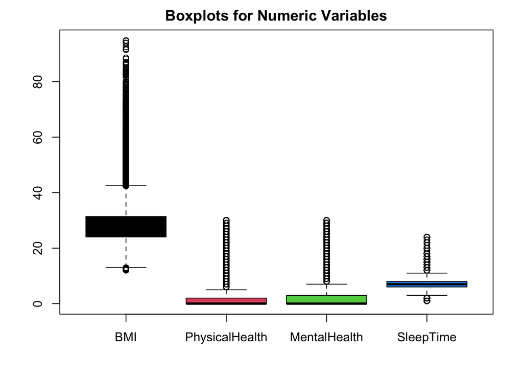

```r
numeric_columns <- df[sapply(df, is.numeric)]

# Setting up a single row for subplots
par(mfrow=c(1, 1), mar=c(4, 4, 2, 2))  # Adjust the 'mar' parameter for margin space

# Creating boxplots for each numeric variable in a single plot with different y-axes
boxplot(numeric_columns, main="Boxplots for Numeric Variables", col=1:length(colnames(numeric_columns)), names=colnames(numeric_columns))
```

```r
numeric_columns <- df[sapply(df, is.numeric)]

# Summary statistics for numeric variables
summary_data <- summary(numeric_columns)

# Print the summary data
print(summary_data)
```

```
##       BMI        PhysicalHealth    MentalHealth      SleepTime
##  Min.   :12.02   Min.   : 0.000   Min.   : 0.000   Min.   : 1.000
##  1st Qu.:24.03   1st Qu.: 0.000   1st Qu.: 0.000   1st Qu.: 6.000
##  Median :27.34   Median : 0.000   Median : 0.000   Median : 7.000
##  Mean   :28.33   Mean   : 3.372   Mean   : 3.898   Mean   : 7.097
##  3rd Qu.:31.42   3rd Qu.: 2.000   3rd Qu.: 3.000   3rd Qu.: 8.000
##  Max.   :94.85   Max.   :30.000   Max.   :30.000   Max.   :24.000
```

```r
# Calculem els límits de les caixes de Tukey
Q1 <- quantile(df$BMI, 0.25)
Q3 <- quantile(df$BMI, 0.75)
IQR <- Q3 - Q1

# Límits inferior i superior per a outliers
lower_limit <- Q1 - 1.5 * IQR
upper_limit <- Q3 + 1.5 * IQR

# Identifiquem els outliers
outliers <- df$BMI[df$BMI < lower_limit | df$BMI > upper_limit]

# Mostrem els outliers
cat("Outliers:", length(outliers) )
```

```
## Outliers: 10396
```

```r
# Replace outlier
# # Calculate the IQR (Interquartile Range)
#IQR <- Q3 - Q1

# Define the lower and upper bounds for outliers
#lower_bound <- Q1 - 1.5 * IQR
#upper_bound <- Q3 + 1.5 * IQR

# Replace outliers with the nearest non-outlier value
#df$BMI[df$BMI < lower_bound] <- lower_bound
#df$BMI[df$BMI > upper_bound] <- upper_bound
```

**Categòriques**

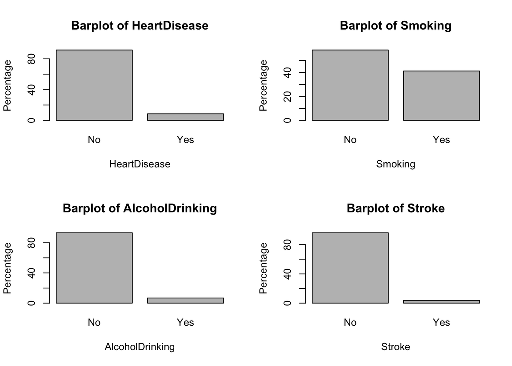

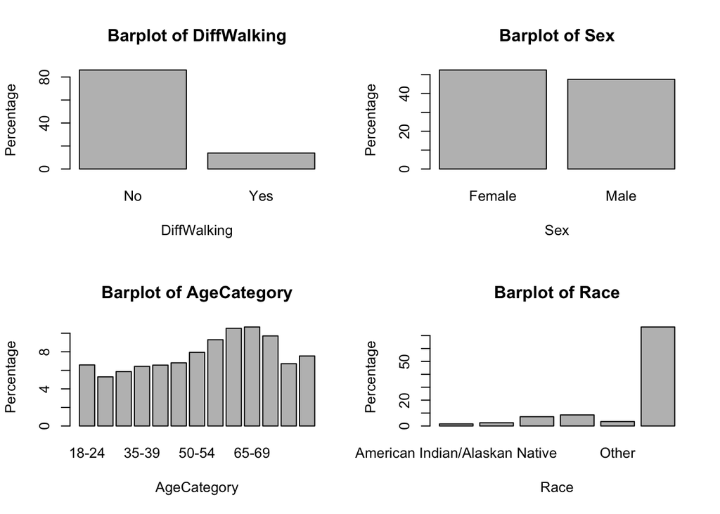

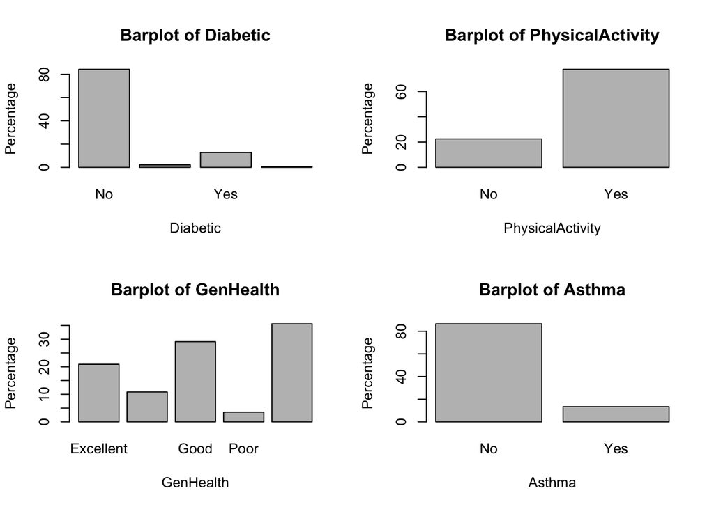

```r
categorical_columns <- df[sapply(df, function(x) is.factor(x) | is.character(x))]

# Setting up a layout for multiple plots
par(mfrow=c(2, 2))  # You can adjust the dimensions based on the number of categorical variables

# Creating barplots for each categorical variable
for (column in colnames(categorical_columns)) {
  # Calculate percentages
  percentages <- table(df[[column]]) / nrow(df) * 100

  # Create barplot
  barplot(percentages, main=paste("Barplot of", column), xlab=column, ylab="Percentage")
}
```

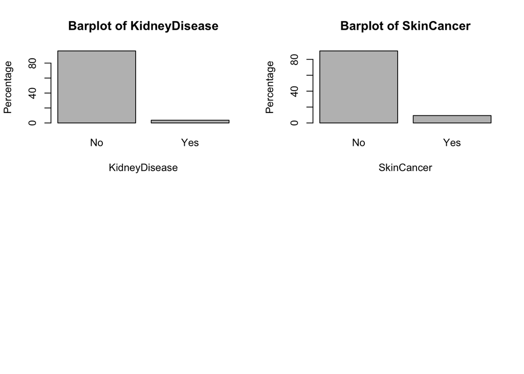

```r
# Reset the layout for the next plot
par(mfrow=c(1, 1))
```

3.3. Convertim la columna de diabetes a dos categories

```r
df[df$Diabetic == "No, borderline diabetes", ]$Diabetic <- "No"
df[df$Diabetic == "Yes (during pregnancy)", ]$Diabetic <- "Yes"
```

3.3. Convertim la columna de GeneralHealth a numèrica per poder fer correlacions després:

```r
unique(df$GenHealth)
```

```
## [1] "Very good" "Fair"      "Good"      "Poor"      "Excellent"
```

```r
#Excellent -> 5
#Very good -> 4
#Good -> 3
#Fair -> 2
#Poor -> 1
gen_health_mapping <- c("Poor" = 1, "Fair" = 2, "Good" = 3, "Very good" = 4, "Excellent" = 5)

# Apply the mapping to create a new column
df <- df %>%
  mutate(GenHealth_numeric = factor(GenHealth, levels = names(gen_health_mapping), labels = gen_health_mapping))

write.csv(df, "../data/heart_2020_cleaned")
```

## 4. Resolució del problema/Anàlisi de dades

### 4.1. Selecció dels grups de dades i tipus d’anàlisis

1 - Prevalència de malaltia segons el sexe: Es calculara la freqüència de cada malaltia segons el sexe dels participants mitjançant 6 variables categòriques (la variable de sexe i cada variable corresponent a les malalties). 2 - Associació de malaltia amb sexe. Com que estem parlant de dos grups de variables categòriques apliquem un Chi Square Test per mirar l’associació. 3 - Prevalència i associació de càncer de pell segons raça. Per mirar la prevàlencia mirem altre cop la freqüència mentre que per estudiar l’assoaició utilitzem un model logisitic (GLM) ja que els dos grups de varibales (raça i sexe) son categòriques. 4 - Associaicó o relaicó d’hores de son segons l’edat. en aqeusts cas estem estudiant una variable numèrica amb una de categ`rocia pel que aplicarem un test d’ANOVA per veure si hi ha o no associació. També es podria aplciar el test de Krusal-Wallis test. 5 - Per estudiar la correlació entre es diversos factors de risc per les malalties cardiosvasculars i la diabetes fem una anàlszi de correlaicó aplican Pearson’s ja que estem comparant variables categòriques.

### 4.2.1 Anàlisis 1: Prevalència de malaltia segons sexe, edat i etnicitat

**Sexe** Mostra la distribució de presencia/absència de malaltia per sexe

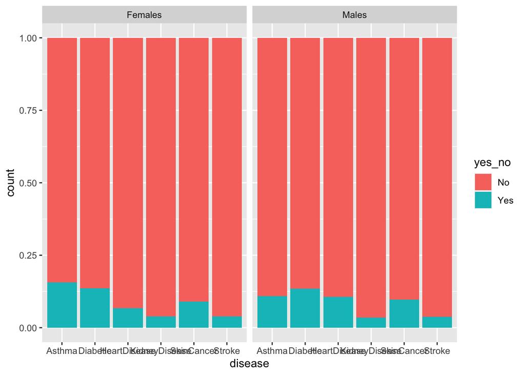

```r
females  <- df %>% filter(Sex == "Female") %>% dplyr::select(HeartDisease, Stroke, Diabetic, Asthma, KidneyDisease, SkinCancer) %>% pivot_longer(cols = c(HeartDisease, Stroke, Diabetic, Asthma, KidneyDisease, SkinCancer), names_to = "disease", values_to = "yes_no")

females$Sex <- "Females"

males  <- df %>% filter(Sex == "Male") %>% dplyr::select(HeartDisease, Stroke, Diabetic, Asthma, KidneyDisease, SkinCancer) %>% pivot_longer(cols = c(HeartDisease, Stroke, Diabetic, Asthma, KidneyDisease, SkinCancer), names_to = "disease", values_to = "yes_no")
males$Sex <- "Males"

df_males_females <- rbind(females, males)

ggplot(df_males_females, aes(disease, fill=yes_no))+geom_bar(stat="count", position="fill")+facet_grid(~Sex)
```

De la gent que té una malaltia, quin és el percentage d’homes i dones?

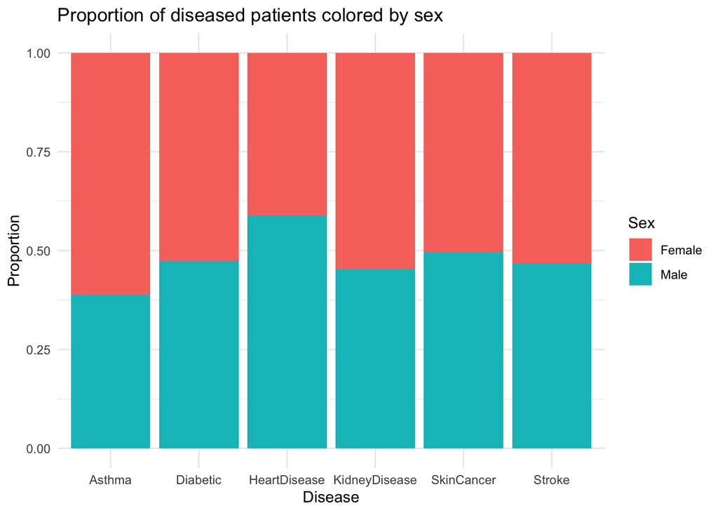

```r
vars <- c("HeartDisease", "Stroke", "Diabetic", "Asthma", "KidneyDisease", "SkinCancer")

new_df <- c("Disease"=NULL, "Sex"=NULL)
for(var in vars){
  df_var <- df[, c(var, "Sex")]
  df_var <- df_var[df_var[var] == "Yes",]
  df_var$Disease <- var
  df_var <- df_var[,-1]
  new_df <- rbind(new_df, df_var)
}

ggplot(new_df, aes(x=Disease, fill=Sex))+geom_bar(stat="count", position = "fill")+ylab("Proportion")+theme_minimal()+ggtitle("Proportion of diseased patients colored by sex")
```

Aquests resultats ens mostren que tot i que la distribució per malaltia entre sexes és sobre el 50% en la majoria dels casos, veiem que sembla que en Asma positiu hi hagi un major percentage de dones i en HeartDisease d’homes.

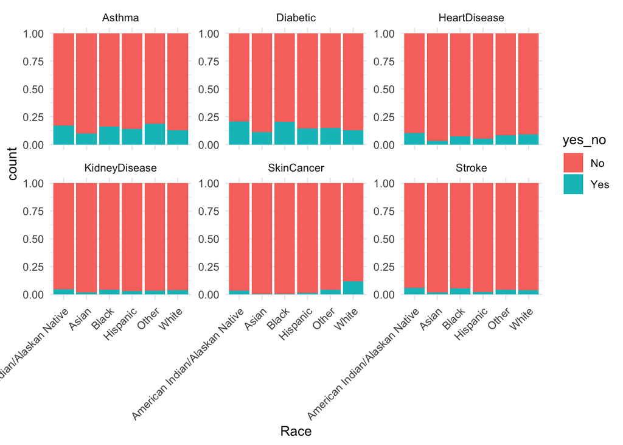

```r
# Select relevant columns and pivot data
race_data <- df %>%
  dplyr::select(Race, HeartDisease, Stroke, Diabetic, Asthma, KidneyDisease, SkinCancer) %>%
  pivot_longer(cols = c(HeartDisease, Stroke, Diabetic, Asthma, KidneyDisease, SkinCancer), names_to = "disease", values_to = "yes_no")

# Create individual plots for each disease
ggplot(race_data, aes(x = Race, fill = yes_no)) +
  geom_bar(stat = "count", position = "fill") +
  facet_wrap(~disease, scales = "free_y", ncol = 3) +
  theme_minimal() +
  theme(axis.text.x = element_text(angle = 45, hjust = 1))  # Adjust x-axis label angle if needed
```

Podem observar que la majoria de malalties les distribucions son semblant en les diferents ascendencies però que en el cas de càncer de pell si que es veu una diferència segons el tipus d’ascencencia. Una altra manera de visualitzar-ho seria amb un stacked barplot on podem veure altre cop que en cas de cancer de pell l’ascendencia europea (white) és més prevalent en aquest tipus de cancer.

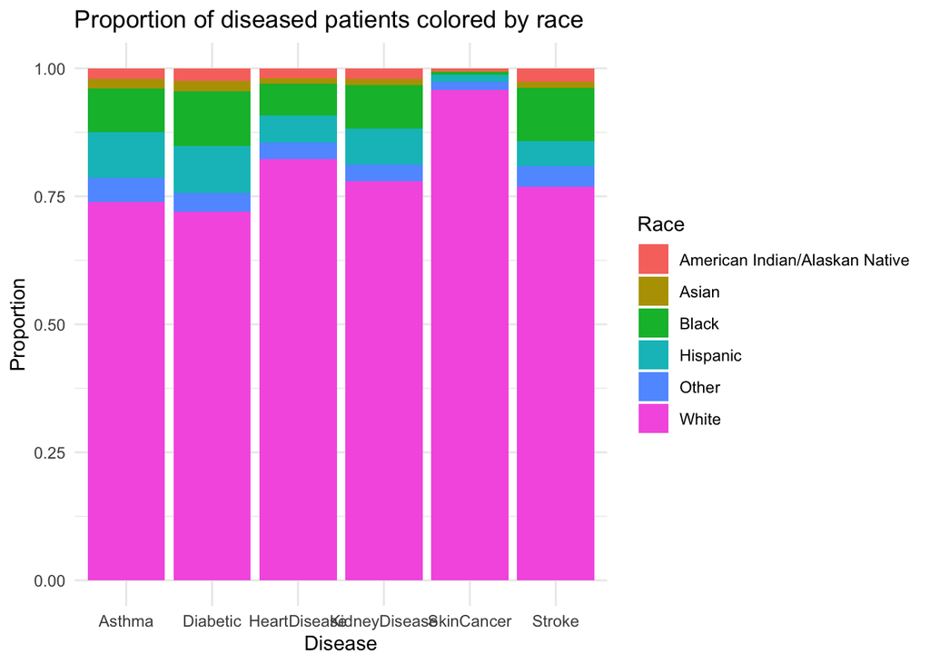

```r
vars <- c("HeartDisease", "Stroke", "Diabetic", "Asthma", "KidneyDisease", "SkinCancer")

new_df <- c("Disease"=NULL, "Sex"=NULL)
for(var in vars){
  df_var <- df[, c(var, "Race")]
  df_var <- df_var[df_var[var] == "Yes",]
  df_var$Disease <- var
  df_var <- df_var[,-1]
  new_df <- rbind(new_df, df_var)
}

ggplot(new_df, aes(x=Disease, fill=Race))+geom_bar(stat="count", position = "fill") + ylab("Proportion")+theme_minimal() +ggtitle("Proportion of diseased patients colored by race")
```

**Edat** Mostra la distribució de presencia/absència de malaltia per edat

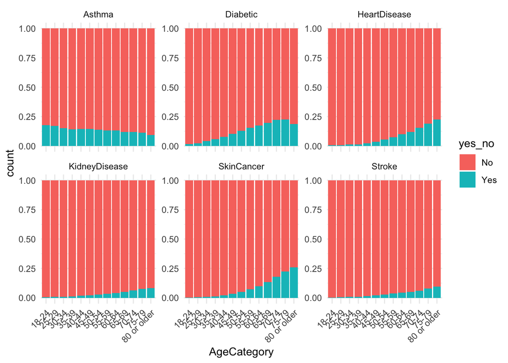

```r
# Select relevant columns and pivot data
disease_data <- df %>%
  dplyr::select(AgeCategory, HeartDisease, Stroke, Diabetic, Asthma, KidneyDisease, SkinCancer) %>%
  pivot_longer(cols = c(HeartDisease, Stroke, Diabetic, Asthma, KidneyDisease, SkinCancer), names_to = "disease", values_to = "yes_no")

# Create individual plots for each disease
ggplot(disease_data, aes(x = AgeCategory, fill = yes_no)) +
  geom_bar(stat = "count", position = "fill") +
  facet_wrap(~disease, scales = "free_y", ncol = 3) +
  theme_minimal() +
  theme(axis.text.x = element_text(angle = 45, hjust = 1))  # Adjust x-axis label angle if needed
```

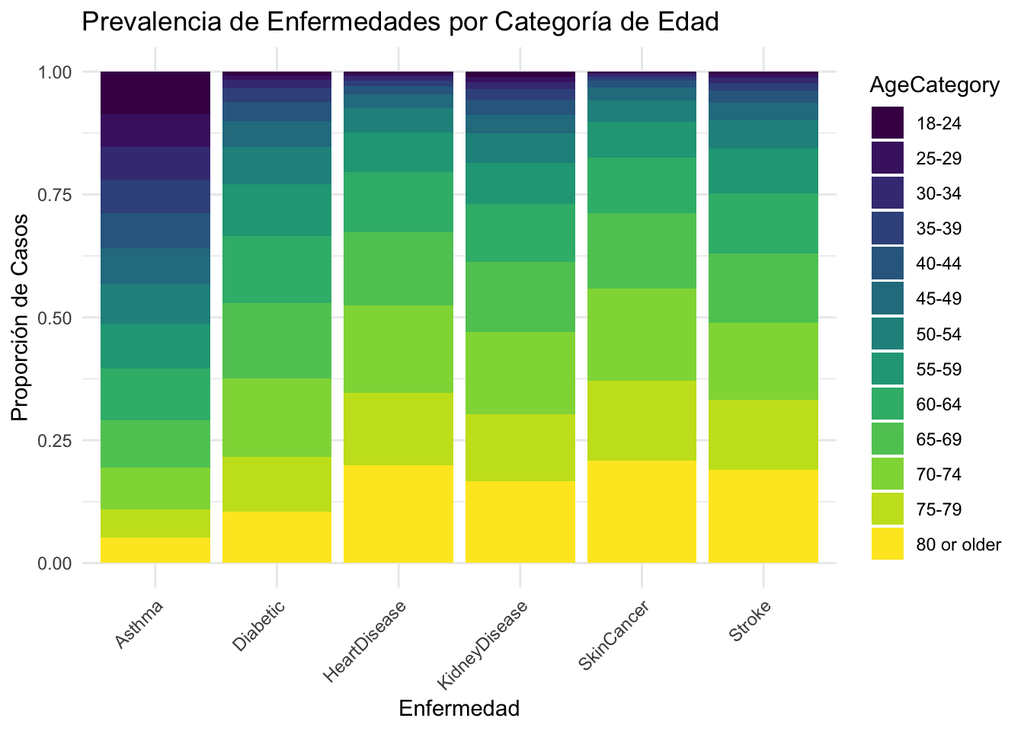

```r
# Define a color scale for diseases
disease_colors <- c("HeartDisease" = "red", "Stroke" = "blue", "Diabetic" = "green",
                     "Asthma" = "purple", "KidneyDisease" = "orange", "SkinCancer" = "brown")
yes_data <- disease_data %>% filter(yes_no == "Yes")

ggplot(yes_data, aes(x = disease, fill = AgeCategory)) +
  geom_bar(position = "fill") +
  theme_minimal() +
  scale_fill_viridis_d() +  # Utilizar la paleta de colores viridis

  labs(title = "Prevalencia de Enfermedades por Categoría de Edad",
       x = "Enfermedad",
       y = "Proporción de Casos") +
  theme(axis.text.x = element_text(angle = 45, hjust = 1))  # Ajustar el ángulo de las etiquetas del eje x si es necesario
```

### 4.2. Anàlisis 2: Associacio Asma i malaltia cardovascular - sexe

Hem vist que hi ha una prevalència d’Asthma en dones superior a homes, per altra banda en el cas de malalties cardiosvaculars es veu una major prevalencia en homes. Per veure si hi ha una assocació entre sexe i aquestes malaltia fem un **ChiSquare**, ja que aquest ja que ambdues variables son categòriques. Així podrem veure si realment aquesta major prevalencia esta indiciant que el sexe femení es un factor de risc per patir asma o no i, si el sexe masculi es un factor de risc per malalties caridosvasculars. Primer fem el test amb Asma:

```r
contingency_table_Astma <- table(df$Sex, df$Asthma)
chisq.test(contingency_table_Astma)
```

```
##
##  Pearson's Chi-squared test with Yates' continuity correction
##
## data:  contingency_table_Astma
## X-squared = 1530.6, df = 1, p-value < 2.2e-16
```

Els resultats ens mostren un p-valor significatiu que ens permet rebutjar la hipòtesi nul·la i per tant podem dir que hi ha una associació entre Sexe i Asma

Ara fem el test amb Malaltia Cardiovascular

```r
contingency_table_HeartDisease<- table(df$Sex, df$HeartDisease)
chisq.test(contingency_table_HeartDisease)
```

```
##
##  Pearson's Chi-squared test with Yates' continuity correction
##
## data:  contingency_table_HeartDisease
## X-squared = 1568.3, df = 1, p-value < 2.2e-16
```

Un altre cop obtenim resultats significatius que ens permeten afirmar que hi ha assocació entre Sexe i malaltia cardiovascular

```r
contingency_table_Skin<- table(df$Sex, df$SkinCancer)
chisq.test(contingency_table_Skin)
```

```
##
##  Pearson's Chi-squared test with Yates' continuity correction
##
## data:  contingency_table_Skin
## X-squared = 57.62, df = 1, p-value = 3.18e-14
```

### 4.3. Anàlisis 3: Associacio color de pell - cancer de pell

Hi ha molts estudis que associen el color de pell amb un increment de risk de patir cancer de pell (https://www.ncbi.nlm.nih.gov/pmc/articles/PMC7087065/). Per tant, en aquesta part del nostre estudi ens volem enfocar en veure com de forta és la influència del color de pell (en aquest cas agafarem la raça) en la presència de cancer de pell. Per fer-ho utilitzarem una regressió logística amb Race com a variable predictiva corregint per Sexe, Edat i Fumadors (s’ha vist que fumar pot ser un factor de risk del cancer de pell) que podrien ser possibles confounders.

Primer però anem a fer una inspecció visual de les dades.

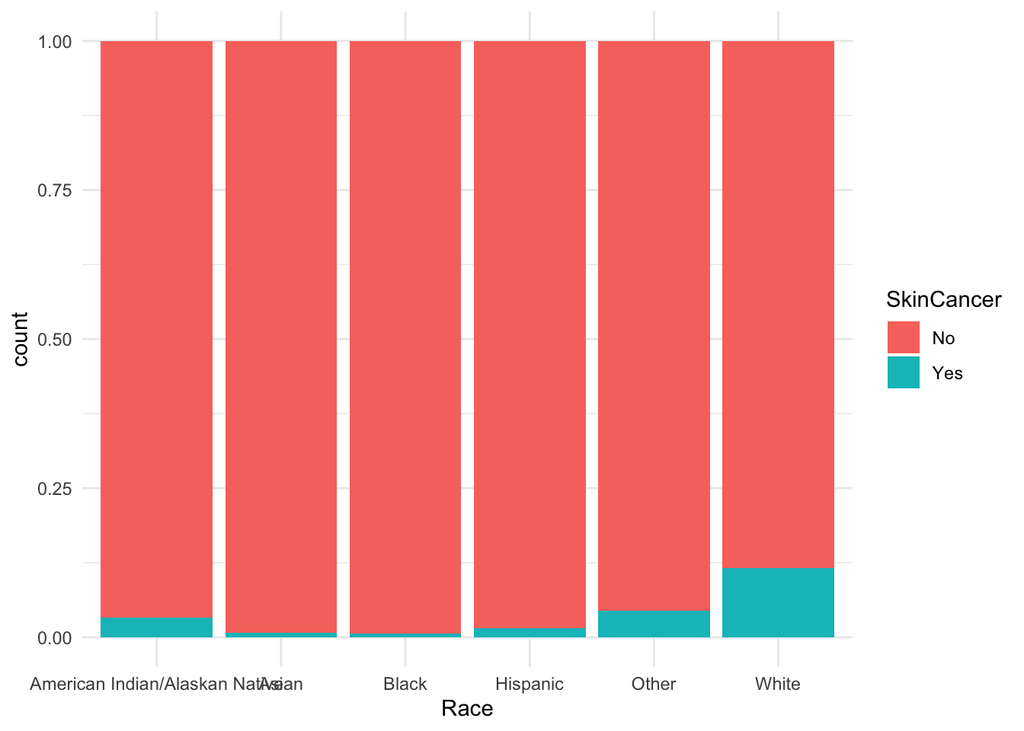

```r
ancestry  <- df %>% dplyr::select(Race, SkinCancer)

ggplot(ancestry, aes(Race, fill=SkinCancer))+geom_bar(stat="count", position="fill")+theme_minimal()
```

Tal com esperàvem, hi ha un percentage més alt de persones amb pell blanc que tenen cancer de pell. Ara procedim a fer el model per veure com de forta és la influència del color de pell:

```r
# Convertim skin cancer a binari
df$SkinCancer <- ifelse(df$SkinCancer == "Yes", 1, 0 )
df$SkinCancer  <- as.factor(df$SkinCancer )
df$Race <- as.factor(df$Race)
df$Sex <- as.factor(df$Sex)
df$AgeCategory <- as.factor(df$AgeCategory)
df$AgeCategory <- as.factor(df$AgeCategory)

# Fit logistic regression model
model <- glm(SkinCancer ~ Race + Sex + AgeCategory + Smoking, data = df, family = "binomial")

# Display model summary
summary(model)
```

```
##
## Call:
## glm(formula = SkinCancer ~ Race + Sex + AgeCategory + Smoking,
##     family = "binomial", data = df)
##
## Coefficients:
##                        Estimate Std. Error z value Pr(>|z|)
## (Intercept)            -6.61528    0.14588 -45.346  < 2e-16 ***
## RaceAsian              -1.34356    0.15648  -8.586  < 2e-16 ***
## RaceBlack              -1.82427    0.11671 -15.631  < 2e-16 ***
## RaceHispanic           -0.46992    0.09383  -5.008 5.50e-07 ***
## RaceOther               0.38537    0.09266   4.159 3.20e-05 ***
## RaceWhite               1.08620    0.07957  13.651  < 2e-16 ***
## SexMale                 0.22029    0.01294  17.026  < 2e-16 ***
## AgeCategory25-29        0.42619    0.16467   2.588  0.00965 **
## AgeCategory30-34        0.95917    0.14614   6.563 5.26e-11 ***
## AgeCategory35-39        1.35563    0.13736   9.869  < 2e-16 ***
## AgeCategory40-44        1.79769    0.13221  13.597  < 2e-16 ***
## AgeCategory45-49        2.38855    0.12788  18.678  < 2e-16 ***
## AgeCategory50-54        2.73539    0.12581  21.743  < 2e-16 ***
## AgeCategory55-59        3.09177    0.12451  24.831  < 2e-16 ***
## AgeCategory60-64        3.39971    0.12388  27.444  < 2e-16 ***
## AgeCategory65-69        3.73214    0.12355  30.208  < 2e-16 ***
## AgeCategory70-74        4.05777    0.12344  32.873  < 2e-16 ***
## AgeCategory75-79        4.33293    0.12366  35.040  < 2e-16 ***
## AgeCategory80 or older  4.51191    0.12344  36.553  < 2e-16 ***
## SmokingYes             -0.00777    0.01296  -0.600  0.54883
## ---
## Signif. codes:  0 '***' 0.001 '**' 0.01 '*' 0.05 '.' 0.1 ' ' 1
##
## (Dispersion parameter for binomial family taken to be 1)
##
##     Null deviance: 198260  on 319794  degrees of freedom
## Residual deviance: 165624  on 319775  degrees of freedom
## AIC: 165664
##
## Number of Fisher Scoring iterations: 8
```

Els resultats d’aquest model ens mostren, tal com esperàvem, que Race contribueix significativament al cancer en tots els casos. Si ens fixem en el primer valor (Estimate) podem saber si l’associació és positiva o negativa. Aquest valor fa referència al log odds ratio de l’associació, el simbol ens indica si aquesta associació és positiva o negativa i el número la intensitat d’aquesta. Per tant veiem que *RaceAsian*, *RaceBlack*, *RaceHispanic* tenen una associació negativa, és a dir, en menys risc de càncer sent la raça negra la associació més forta. En canvi, *RaceOthers* i *RaceWhite* tenen una associació positivia suggerint un increment del risc en aquests dos grups racials.

Inesperadament, també trobem una associació significativa amb Homes i en totes les franges d’edat fet que corrobora la necessitat de posar aquestes variables al model per evitar resultats falsos i confusos.

### 4.4. Anàlisis 4: Impacte sleep time on age

Per tal d’estudiar si les hores de son estan relaciona o no amb l’edat aplicarem un test d’ANOVA. Com a alternativa en cas de tenir una gran homogeneitat també es podria aplicar un test de Kurskal-Willis en comptes d’un ANOVA.

```r
# Check correlation using ANOVA
anova_result <- aov(SleepTime ~ AgeCategory, data = df)
print(summary(anova_result))
```

```
##                 Df Sum Sq Mean Sq F value Pr(>F)
## AgeCategory     12  14310    1192   591.1 <2e-16 ***
## Residuals   319782 645142       2
## ---
## Signif. codes:  0 '***' 0.001 '**' 0.01 '*' 0.05 '.' 0.1 ' ' 1
```

```r
# Alteernatia: cKruskal-Wallis test (non-parametric)
#kruskal_result <- kruskal.test(SleepTime ~ AgeCategory, data = df)
#print(kruskal_result)
```

El baix valor de p (<0,001) indica que les diferències observades no són probablement a causa dels atzar. Pel que podem concloure que hi Hi ha diferències significatives en les mitjanes de ‘SleepTime’ entre diferents nivells de ‘AgeCategory’.

Com que el resultat és significatiu també mirarem si hi ha diferències segons els grups d’edat mitjantcant una prova de TukeyHSD.

```r
# Perform Tukey's HSD post-hoc test
tukey_result <- TukeyHSD(anova_result)
# Bonferroni correction
adjusted_tukey_result <- glht(anova_result, linfct = mcp(AgeCategory = "Tukey"))
print(summary(adjusted_tukey_result))
```

```
##
##   Simultaneous Tests for General Linear Hypotheses
##
## Multiple Comparisons of Means: Tukey Contrasts
##
##
## Fit: aov(formula = SleepTime ~ AgeCategory, data = df)
##
## Linear Hypotheses:
##                          Estimate Std. Error t value Pr(>|t|)
## 25-29 - 18-24 == 0       -0.20000    0.01465 -13.647    <0.01 ***
## 30-34 - 18-24 == 0       -0.31377    0.01426 -22.003    <0.01 ***
## 35-39 - 18-24 == 0       -0.33149    0.01393 -23.803    <0.01 ***
## 40-44 - 18-24 == 0       -0.30949    0.01385 -22.346    <0.01 ***
## 45-49 - 18-24 == 0       -0.28239    0.01372 -20.576    <0.01 ***
## 50-54 - 18-24 == 0       -0.26227    0.01324 -19.811    <0.01 ***
## 55-59 - 18-24 == 0       -0.22095    0.01279 -17.275    <0.01 ***
## 60-64 - 18-24 == 0       -0.12733    0.01248 -10.205    <0.01 ***
## 65-69 - 18-24 == 0        0.01579    0.01244   1.269   0.9886
## 70-74 - 18-24 == 0        0.12031    0.01268   9.490    <0.01 ***
## 75-79 - 18-24 == 0        0.22582    0.01377  16.396    <0.01 ***
## 80 or older - 18-24 == 0  0.35437    0.01339  26.464    <0.01 ***
## 30-34 - 25-29 == 0       -0.11377    0.01505  -7.559    <0.01 ***
## 35-39 - 25-29 == 0       -0.13150    0.01474  -8.923    <0.01 ***
## 40-44 - 25-29 == 0       -0.10949    0.01466  -7.467    <0.01 ***
## 45-49 - 25-29 == 0       -0.08239    0.01455  -5.664    <0.01 ***
## 50-54 - 25-29 == 0       -0.06228    0.01409  -4.420    <0.01 ***
## 55-59 - 25-29 == 0       -0.02095    0.01367  -1.533   0.9480
## 60-64 - 25-29 == 0        0.07267    0.01337   5.433    <0.01 ***
## 65-69 - 25-29 == 0        0.21579    0.01334  16.171    <0.01 ***
## 70-74 - 25-29 == 0        0.32031    0.01356  23.618    <0.01 ***
## 75-79 - 25-29 == 0        0.42582    0.01459  29.183    <0.01 ***
## 80 or older - 25-29 == 0  0.55437    0.01423  38.955    <0.01 ***
## 35-39 - 30-34 == 0       -0.01772    0.01434  -1.235   0.9909
## 40-44 - 30-34 == 0        0.00428    0.01427   0.300   1.0000
## 45-49 - 30-34 == 0        0.03138    0.01415   2.218   0.5737
## 50-54 - 30-34 == 0        0.05150    0.01368   3.765   0.0104 *
## 55-59 - 30-34 == 0        0.09283    0.01324   7.009    <0.01 ***
## 60-64 - 30-34 == 0        0.18644    0.01294  14.407    <0.01 ***
## 65-69 - 30-34 == 0        0.32956    0.01291  25.529    <0.01 ***
```

[output cut: 36 more lines]

```
## 75-79 - 55-59 == 0        0.44677    0.01272  35.133    <0.01 ***
## 80 or older - 55-59 == 0  0.57532    0.01230  46.768    <0.01 ***
## 65-69 - 60-64 == 0        0.14311    0.01091  13.121    <0.01 ***
## 70-74 - 60-64 == 0        0.24764    0.01117  22.164    <0.01 ***
## 75-79 - 60-64 == 0        0.35315    0.01240  28.476    <0.01 ***
## 80 or older - 60-64 == 0  0.48170    0.01198  40.223    <0.01 ***
## 70-74 - 65-69 == 0        0.10452    0.01114   9.386    <0.01 ***
## 75-79 - 65-69 == 0        0.21003    0.01237  16.981    <0.01 ***
## 80 or older - 65-69 == 0  0.33858    0.01194  28.353    <0.01 ***
## 75-79 - 70-74 == 0        0.10551    0.01260   8.371    <0.01 ***
## 80 or older - 70-74 == 0  0.23406    0.01218  19.209    <0.01 ***
## 80 or older - 75-79 == 0  0.12855    0.01332   9.650    <0.01 ***
## ---
## Signif. codes:  0 '***' 0.001 '**' 0.01 '*' 0.05 '.' 0.1 ' ' 1
## (Adjusted p values reported -- single-step method)
```

Diferències signficiatives amb el grup jove:

Per exemple les hores de son son significativament diferents entre el grup d’edat 31-34 i el grup d’edadt 18-24. En canvi sembla ser que no hi ha difereǹcies significatives a nivell d’hores de son entre els més joves (18-24) i el grup de 65-69 anys d’edat.

### 4.5. Anàlisis 5: Esport i hores de son

```r
# Subset the relevant columns
activity_sleep_age_data <- df %>%
  dplyr::select(PhysicalActivity, SleepTime, AlcoholDrinking, Smoking, AgeCategory)

# Convert 'PhysicalActivity', 'AlcoholDrinking', and 'Smoking' to 1 for "Yes" and 0 for "No"
activity_sleep_age_data <- activity_sleep_age_data %>%
  mutate(
    PhysicalActivity = ifelse(PhysicalActivity == "Yes", 1, 0),
    AlcoholDrinking = ifelse(AlcoholDrinking == "Yes", 1, 0),
    Smoking = ifelse(Smoking == "Yes", 1, 0)
  )

# Convert Sleep Time to numeric
activity_sleep_age_data$SleepTime <- as.numeric(activity_sleep_age_data$SleepTime)

# Calculate correlation coefficients
correlation_physical_activity <- cor(activity_sleep_age_data$PhysicalActivity, activity_sleep_age_data$SleepTime)
correlation_alcohol_drinking <- cor(activity_sleep_age_data$AlcoholDrinking, activity_sleep_age_data$SleepTime)
correlation_smoking <- cor(activity_sleep_age_data$Smoking, activity_sleep_age_data$SleepTime)

# Display the correlation coefficients
print(paste("Correlation Coefficient between Physical Activity and Sleep Time: ", correlation_physical_activity))
```

```
## [1] "Correlation Coefficient between Physical Activity and Sleep Time:  0.00384884137943058"
```

```r
print(paste("Correlation Coefficient between Alcohol Drinking and Sleep Time: ", correlation_alcohol_drinking))
```

```
## [1] "Correlation Coefficient between Alcohol Drinking and Sleep Time:  -0.00506545083384176"
```

```r
print(paste("Correlation Coefficient between Smoking and Sleep Time: ", correlation_smoking))
```

```
## [1] "Correlation Coefficient between Smoking and Sleep Time:  -0.0303356350880332"
```

This correlation coefficient is very close to zero, indicating a very weak or negligible linear relationship between Physical Activity and Sleep Time. This suggests a slight tendency for individuals who drink more alcohol to have slightly shorter sleep times, but again, the relationship is very weak. Same for smooking.

## 5 Conclusió

En resum hem observat que: - Hi ha algunes malalties més prevalents segons el sexe. En el cas de l’asma és més prevalent en dones mentre que en el cas de Heart Disease és més prevaent en homes. - La raça blanca és més freqüent tenit càncer de pell en comparació amb altres races. També veiem que *RaceAsian*, *RaceBlack*, *RaceHispanic* tenen menys risc de càncer sent la raça negra la associació més forta. En canvi, *RaceOthers* i *RaceWhite* tenen un major risc de patir aquest càncer. - Observem que els patrons de descnas o hores de son son diversos en els diferents grups d’edat i que en més d’un grup les diferencies son signficiatvies. A més a més, si mirem l’impacte que té realitzar activtiat física, beure alcohol i fumar en dormir més o menys hores veiem que les correlacions entre aqeustes variables son febles pel que no podem concliure que siguin asuestes facotrs de risc els responsables de d’hormir més o menys hores. Per tant, podem concliure que efectivament aquest conjunt de dades permet respondre a les nostres preguntes i que pot servir per detectar brots de malalties o bé factors de risc per aquestes.